# Practica1BigDataAleLopezManuelZamora_v3

## Introducción a Big Data

La siguiente práctica consiste en analizar una base de datos de votaciones en diferentes distritos electorales para los 5 candidatos que vimos en el ejercicio en clase. Para esto, haremos uso de una máquina virtual para poder entrar a ubuntu y posteriormente a Hadoop y ahí hacer el proecesamiento de datos con un Mapper y un Reducer para poder realizar la práctica.

Comencemos a conectarnos a la máquina virtual asociada a la IP que se nos otorgó en clase:

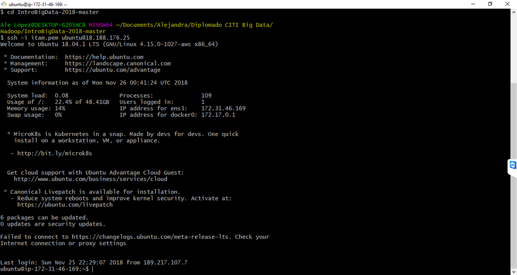

Procedemos conectarnos a Hadoop

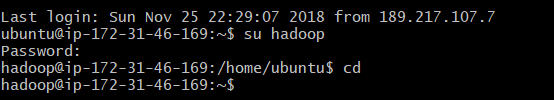

Ahora modificaremos el código en python que tenemos en nuestro Mapper para que quede a nivel distrito y le otorgaremos los permisos correspondientes:

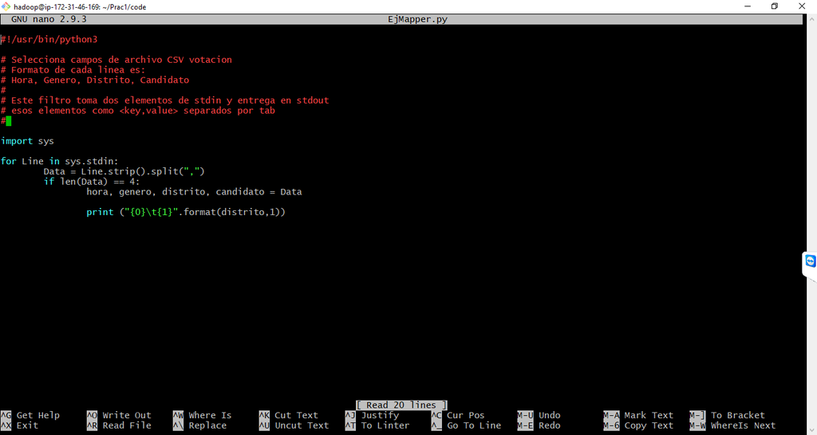

Ahora modificaremos el código en python para nuestro Reducer:

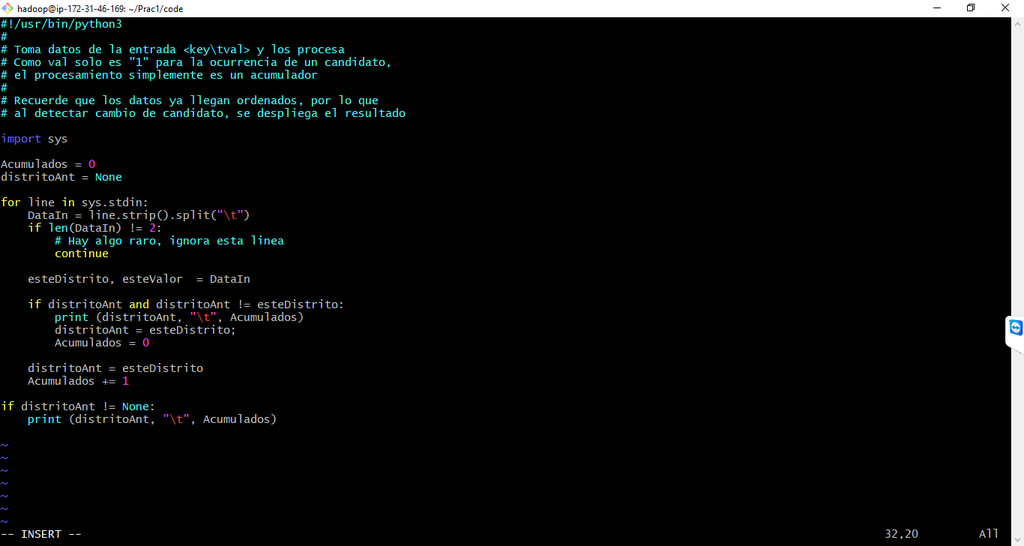

Utilizando el comando de hadoop jar para poner como input el archivo de votación y generar nuestra salida "dist1", utilizaremos los códigos en python de EjMapper y EjReducer:

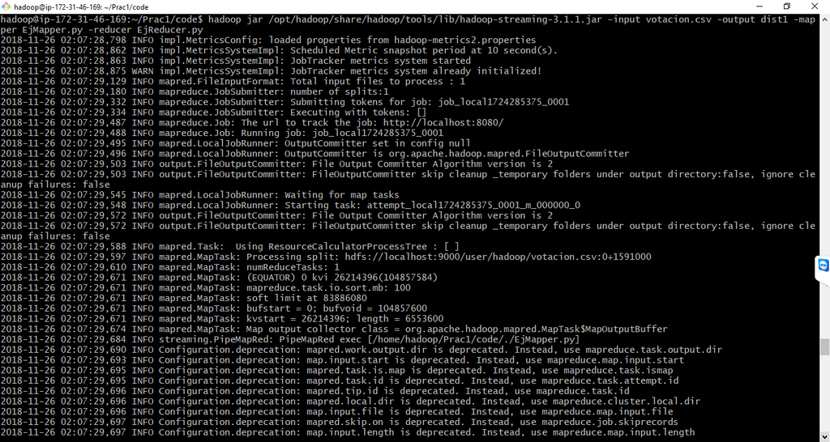

*I. ¿Cuántos distritos electorales contiene el archivo votacion.csv?*

Una vez que ejecutamos los comandos de arriba, obtenemos un archivo que se genera dentro de nuestro output "dist1" el cual tiene el nombre de part-00000

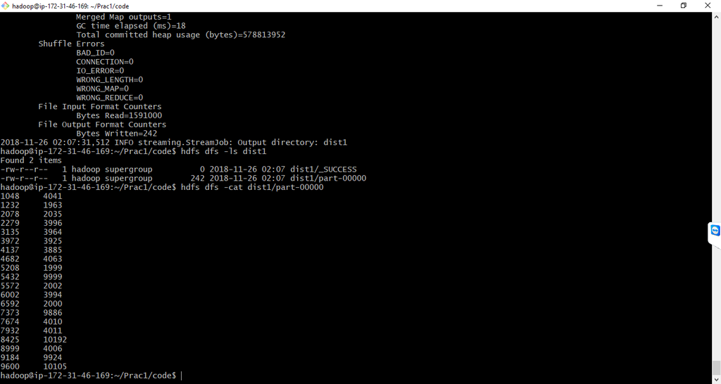

Por lo tanto podemos ver que hay 20 distritos electorales

*II. ¿Cuántas encuestas se obtuvieron por distrito electoral? ¿En qué distrito se capturaron más encuestas? ¿En cuál menos?*

Del ouput de arriba podemos ver que:

En el distrito 8425 fue el distrito que más encuestas tuvo, al contar con 10,192.

El que menos tuvo fue el distrito 1232 que cuenta con 1,963 encuestas

*III. ¿Cuántos votos obtuvo cada candidato en cada distrito electoral? ¿Cuántos obtuvo el candidato 1 en el distrito 1232? ¿Cuántos el candidato 5 en el distrito 9184?*

Para poder llevar a cabo esta pregunta, hicimos una modificación en el Mapper, el cual es:

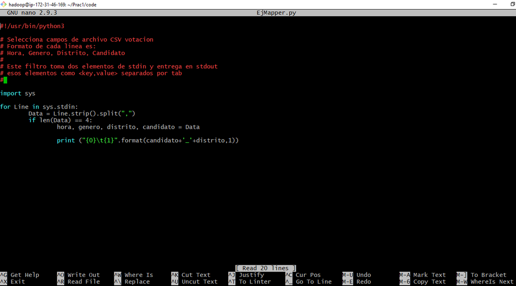

Y sólo renombramos la "llave" en el reducer para que sea genérica de la siguiente forma:

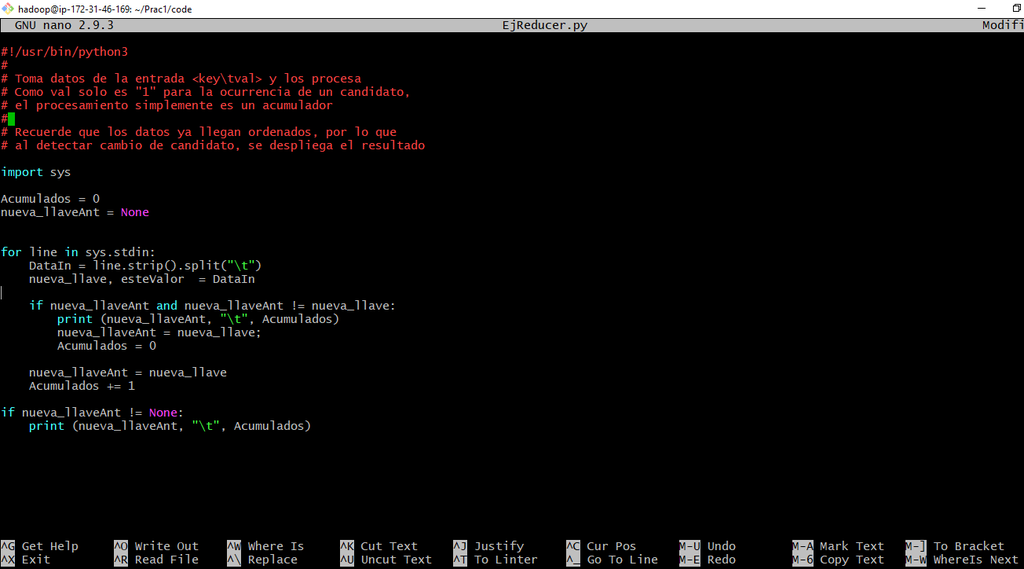

De esta forma tenemos el siguiente output:

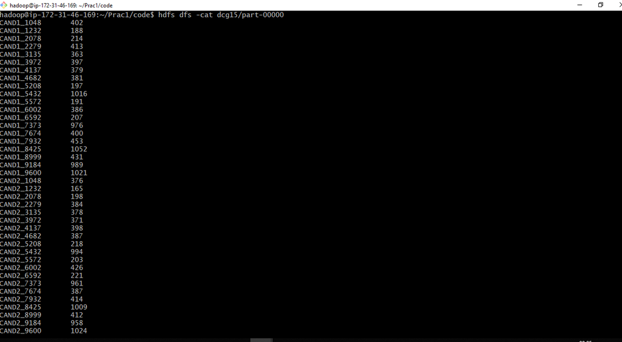

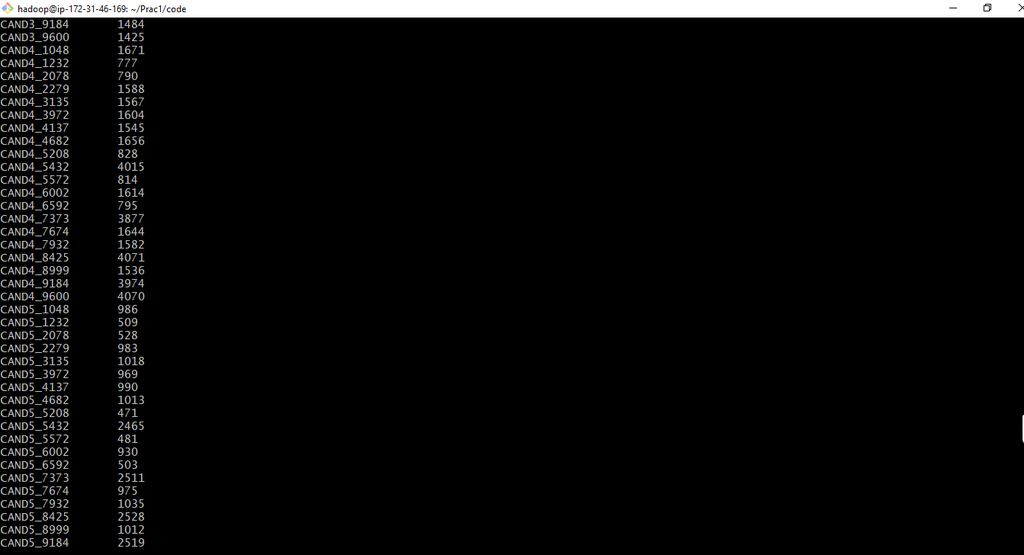

El candidato 1 en el Distrito 1232 tuvo 188 votos. El candidato 5 en el distrito 9184 tuvo 2519 votos.

*IV. ¿Cómo se distribuyó el voto por género para cada candidato en cada distrito electoral? ¿En qué distrito y para qué candidato se obtuvo la menor preferencia electoral de los varones?*

Nuevamente modificamos el Mapper para agregar la variable de género dentro de la llave, de la siguiente forma:

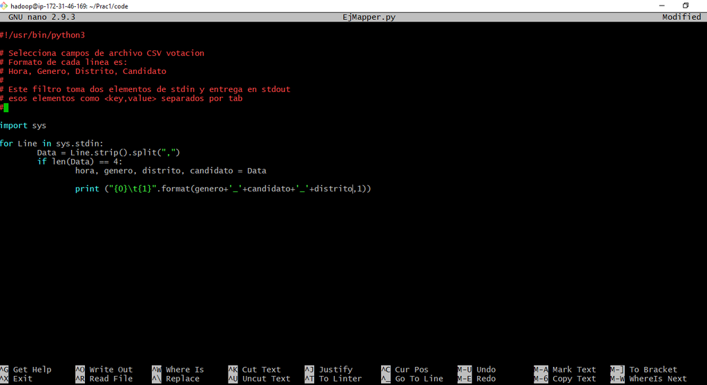

De esta forma tenemos el siguiente ouput, al cual le aplicamos un sort:

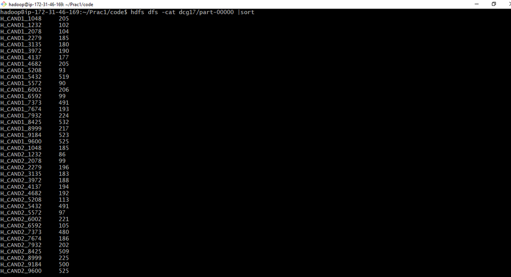

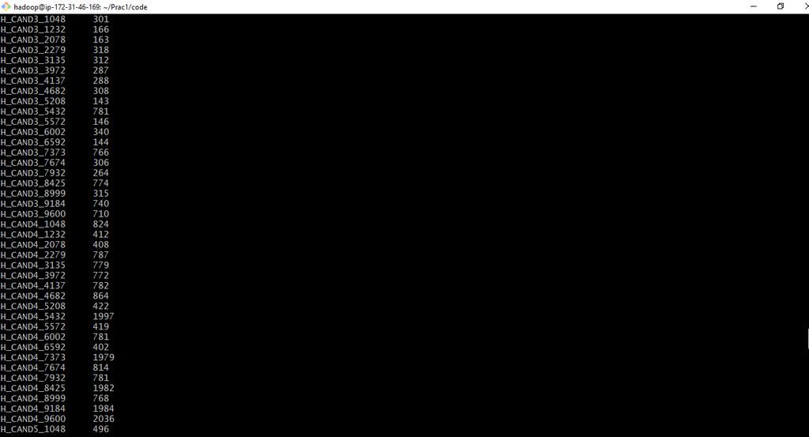

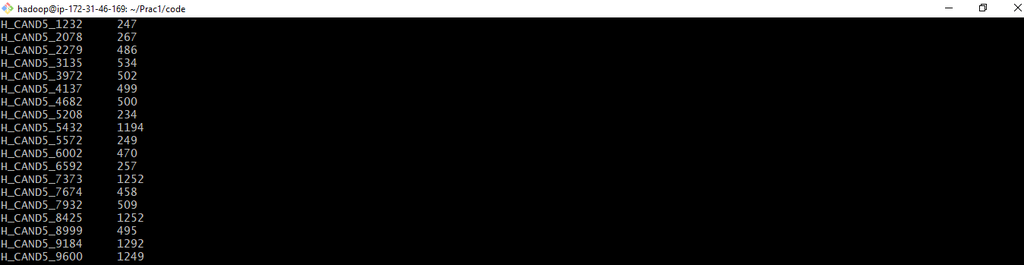

El candidato 2 en el distrito 1232 fue el que tuvo menor cantidad de votos dentro de los hombres

*V. Calcule el histograma de votación por hora para todo el proceso electoral.*

Modificamos el Mapper para que la llave sea con hora, tenemos:

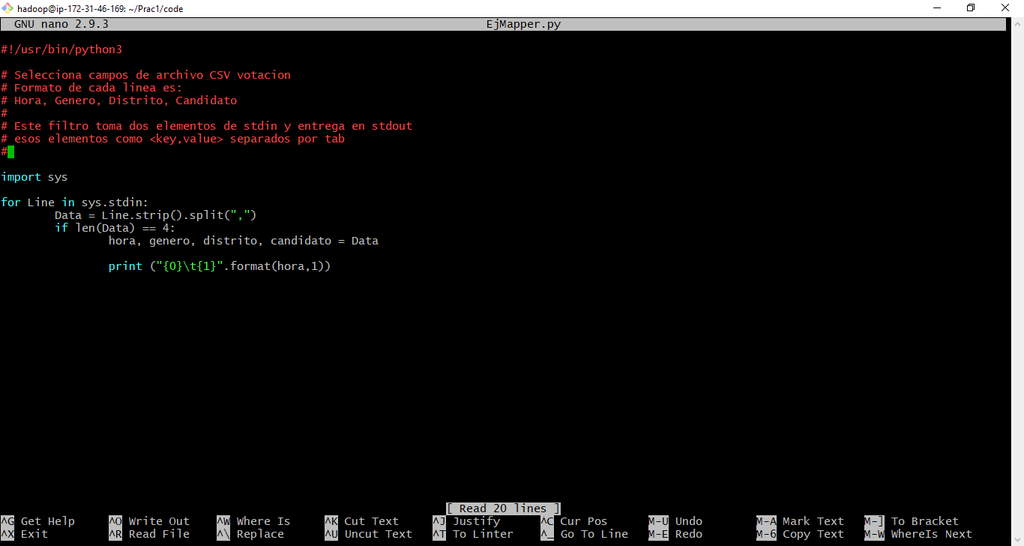

Tenemos el siguiente output:

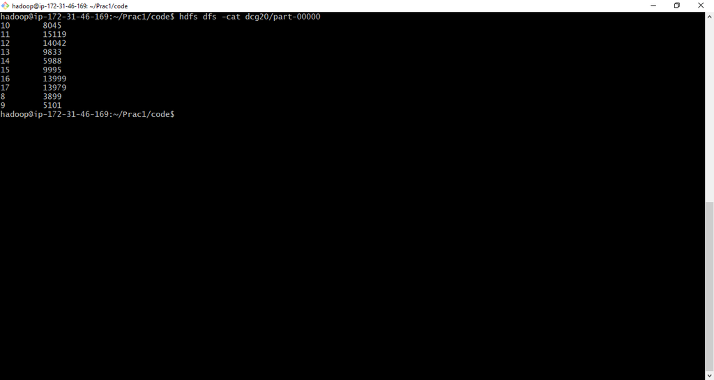

Si lo copiamos y lo pasamos a un csv, podemos hacer el siguiente histograma del proceso electoral por hora:

```python
import pandas as pd
base=pd.read_csv('Horas_Histograma.csv')
display(base)
```

|  | Hora | Total |
| --- | --- | --- |
| 0 | 8 | 3899 |
| 1 | 9 | 5101 |
| 2 | 10 | 8045 |
| 3 | 11 | 15119 |
| 4 | 12 | 14042 |
| 5 | 13 | 9833 |
| 6 | 14 | 5988 |
| 7 | 15 | 9995 |
| 8 | 16 | 13999 |
| 9 | 17 | 13979 |

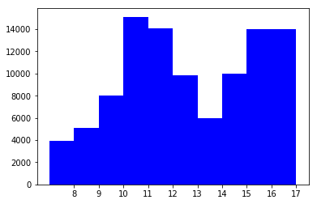

```python
import numpy as np
import matplotlib.pyplot as plt
alphab = base.Hora
frequencies = base.Total

pos = np.arange(len(alphab))
width = 1.0     # gives histogram aspect to the bar diagram

ax = plt.axes()
ax.set_xticks(pos + (width / 2))
ax.set_xticklabels(alphab)

plt.bar(pos, frequencies, width, color='b')
plt.show()
```

Por lo tanto podemos ver que las horas 11,12,16 y 17 son las que tuvieron mayor número de votaciones.